# Coursework Report

*N* removed NAs: 3

*N* removed typo: 1

*N* removed <18: 22

*N* total clean: 124

| Group | *N* | *M*<sub>age</sub> | *M*<sub>rating</sub> |
| --- | --- | --- | --- |
| Control | 63 | 20.5 | 7.01 |
| Experim | 61 | 20.8 | 6.23 |

**Main analysis results**

*t*(122) = 6.12, *p* < .001

[interactive chart not shown]

[figure not shown]

[interactive chart not shown]

# Coursework Report

Analysing Data, Spring 2020

# Methods

## Participants

In this experiment, the effects of the colours white and red on women’s perceptions of a man’s attractiveness were examined. The study initially recruited 150 participants. Recruited participants came to a laboratory and participated in person. After the experiment was concluded, data from 26 participants was removed. 1 participant was removed due to an incorrect age being submitted, because I am unable to confirm their age, their data was removed. A further 22 participants were removed due to them being under the age of 18 for ethical reasons. Finally, 3 participants were removed due to not responding to all the rating scale questions. This left me with 124 participants whose results are included in this analysis (*M*<sub>age</sub> = 20.66, *SD*<sub>age</sub> = 1.94, range = 18 - 26). Table 1 shows the mean and standard deviation of age for the participants in each experimental condition.

Summary of Participant Demographics by Experimental Condition

| Condition | Count | *M*<sub>age</sub> | *SD*<sub>age</sub> |
| --- | --- | --- | --- |
| control | 63 | 20.5 | 1.95 |
| experimental | 61 | 20.8 | 1.94 |

## Design

This study is interested in examining whether colour has an effect on attractiveness ratings, and more specifically if the colours red and white have different effects. The conceptual hypothesis of this study is: does colour influence attractiveness? To operationalise these variables, colour was manipulated by placing a photograph of a man on either a white background for the control group, or a red background for the experimental group. Colour, therefore, is the independent categorical variable. Attractiveness was operationalised by creating three questions which are as follows: how attractive do you think this person is? How pleasant is this person to look at? If I were to meet this person in this picture face to face, I would think he is attractive. Participants were asked to rate these questions on a 9 point scale ranging from 1 (not at all attractive) to 9 (extremely attractive). These scores were then averaged to create a composite score. Attractiveness, therefore, is the continuous dependent variable. The operational hypothesis of this study, then, is: does viewing a white or red background around an image of a man influence the mean ratings of his attractiveness?

In this experiment participants were randomly allocated to one of two experimental conditions. Participants viewed a black-and-white photograph of a moderately attractive Caucasian man, showing his head and torso while wearing a plain shirt. The photo was centred on a page, and then colour was placed on the area surrounding the photo. In the experimental condition, the surrounding area was red. In the control condition, the surrounding area was white. Participants were then asked to rate his attractiveness on three questions, as stated above. A high score indicates that the participant found the man in the photo attractive, whereas a low score indicates they did not. We are interested in if the average scores of attractiveness ratings differ in the experimental groups. If the average score in the experimental group is higher than the control, this would suggest that our colour manipulation of the independent variable had an effect on attractiveness ratings, meaning colour, and more specifically the colour red, does influence attractiveness. An independent-samples t test will be used to examine the influence of colour condition on perceived attractiveness.

# Results

In this study, attractiveness was measured by participants answering 3 questions on a 9 point scale. These rating scores were then averaged to create a composite score. This composite score therefore captures the average attractiveness rating each participant gave to the target man. In this results section, the difference between these composite scores are compared by experimental condition.

As shown in the table below, participants in the white (control) condition, compared with those in the red (experimental) condition, rated the target man as more attractive. The mean composite score in the control condition is 7.01 with a standard deviation of 0.69, and the mean composite score in the experimental condition is 6.23 with a standard deviation of 0.73. It can be seen that there is a difference in mean scores of attractiveness ratings (*M*<sub>diff</sub> = 0.78, 95% CI [0.52, 1.03]). This shows that there is a difference in composite scores in the control condition compared to the experimental condition.

Mean and Standard Deviation of Composite Scores by Experimental Condition

| Condition | Mean | Standard Deviation |
| --- | --- | --- |
| control | 7.01 | 0.69 |
| experimental | 6.23 | 0.73 |

In this analysis, an independent-samples t-test was conducted examining the influence of the colour conditions on perceived attractiveness ratings. The t-test revealed a significant colour effect *t*(122) = 6.12, p < .001 (See Figure 1). These results suggest that colour did influence participant’s ratings. We can conclude from this t-test that we should reject the null hypothesis, and retain the alternative hypothesis - that colour does influence attractiveness ratings.

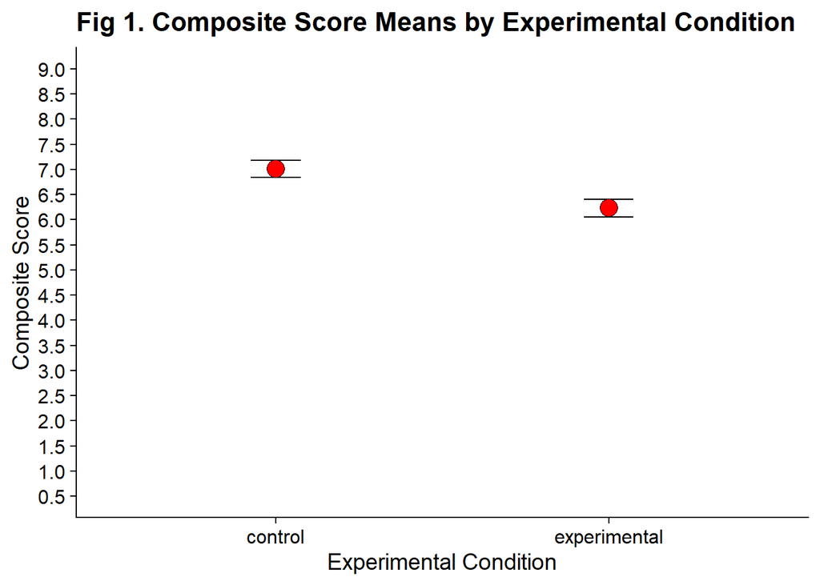

In the graph above (Fig. 1) we can see the composite score means are plotted by experimental condition, and they do differ. The mean score of attractiveness is higher in the control condition, whereby the man was placed on a white background, compared to the experimental condition, whereby the man was placed on a red background. Participants in the control condition perceived the man as more attractive.

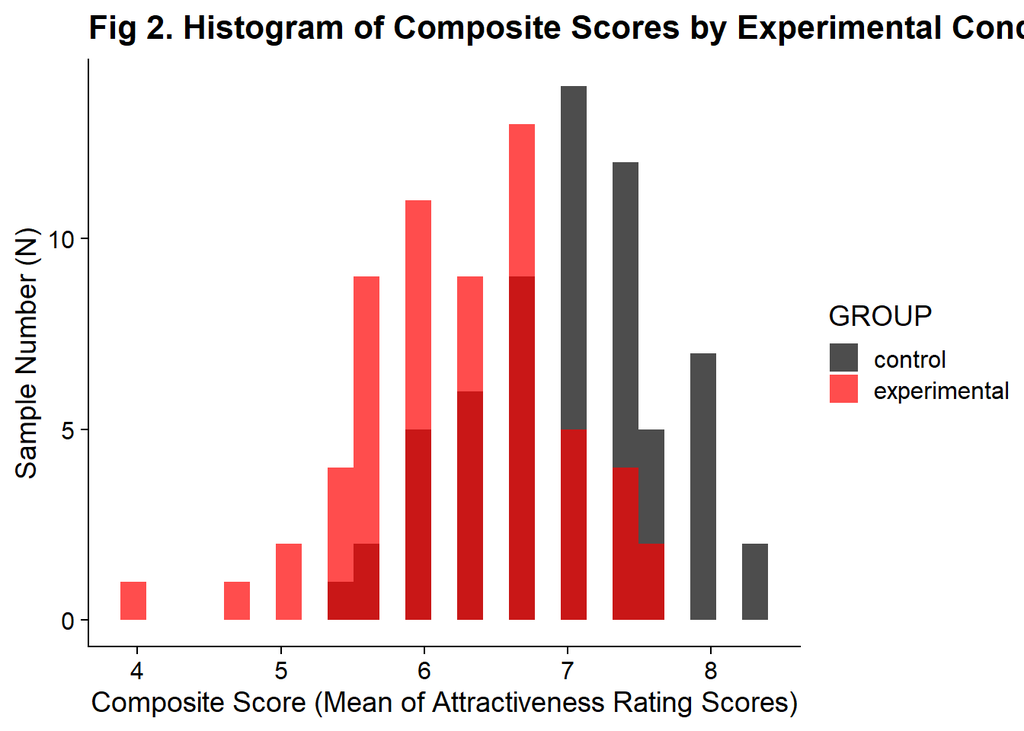

As displayed in the figure above (Fig. 2), participants in the control (white) condition rated the target man as more attractive than did participants in the experimental (red) condition.

# Discussion

This experiment re-examined the influence of colour on attraction, more specifically the red effect found in Elliot’s study (Elliot et al., 2010). The original study found that women perceived men as more attractive when presented on a red background compared to a white background. This present replication attempt concluded a different result. Participant’s in the white condition rated the target man as more attractive compared to the red condition. From the t-test we can conclude that colour did significantly influence participant’s ratings, however due to the control group’s mean attractiveness score being higher than the experimental group’s score, this is not support for the hypothesised red effect – it shows an effect in the opposite direction, perhaps a ‘white effect’.

Controversially, Elliot’s study has been accused of being subject to publication bias (Francis, 2013) because of this Elliot and Maier (Elliot & Maier, 2013) conducted a replication of one of their original studies. Similar to our experiment, they did not find a significant red effect. They did not find a ‘white effect’ either, due to them using a grey condition instead of a white one – perhaps if they used white, they would have found a similar effect to us. Although, considering white was selected because it is such a neutral colour and therefore unobtrusive, perhaps we aren’t seeing attractiveness ratings increase because of the colour white but rather seeing attractiveness ratings decrease because of the colour red.

A study that seems to show the red effect in terms of decreasing attraction comes from Buechner (Buechner et al., 2014) who looked at the influence of colour and emotional expression. They found that for women viewing a man with an expression displaying pride, the colour red lead to higher attractiveness ratings. However, when he was displaying an expression of shame the colour red decreased their ratings of attractiveness. Buechner hypothesised that red accentuates existing response tendencies, making an unappealing target more so. This suggests that in our replication, perhaps the women did not find the male target attractive initially, and the placing of his picture on a red background made him even more unattractive to them. Buechner’s findings suggest that red only enhances attractiveness in men who possess qualities that already evoke attraction in women.

We must also consider the possibility that the red effect isn’t applicable to heterosexual women in the same way it is to heterosexual men. In a study by Elliot et al (Elliot & Niesta, 2008) they conducted a series of 5 experiments and found that red leads men to view women as more sexually desirable and attractive. Another study conducted by Pazda (Pazda et al., 2012) found that men perceive women in red as sexually receptive and therefore more attractive. The influence of red on men’s attraction to women has been demonstrated widely but perhaps the red effect is just not found when the sexes are reversed.

Given that the findings from our experiment differ from the original findings of Elliot (Elliot et al., 2010) we must consider the validity of the original findings, and our own. Both studies can be seen to lack ecological validity for similar reasons. For example, participants were only presented with one photograph. This is highly restrictive and cannot be seen as a reflection of reality because in reality, there is high variability in physical appearance. So, it is difficult to claim that there is a generalisable red effect, or in our experiment the opposite effect, especially when this could be restricted to only the ‘moderately attractive’ males used. Furthermore, other factors were neglected to be considered such as clothing and facial features.

Similarly to the present study, Hesslinger (Hesslinger et al., 2015) replicated Elliot’s (2010) experiment, but did so while addressing some of the ecological validity problems mentioned previously. They did not find red to have any statistically significant impact on attractiveness ratings. This suggests that our results may lack validity and not be generalisable to the larger population. However, Hesslinger did find that apparel style had an effect on perceived attractiveness. They found that men in suits were found more attractive by participants than men in casual sportswear. This suggests that perhaps the style of clothing, rather than the colour, can have a larger effect on perceived attractiveness. Nevertheless, the lack of replicability of the red effect from Hesslinger suggests a problem with the reliability of the study.

Through analysis of the data it was found that there does seem to be a problem with reliability, in particular with the measure of attractiveness. Participants were asked 3 questions and rated their answers on a scale, these three answers were then averaged to create a composite score. If all three questions were measuring attractiveness, we would expect there to be high correlations between them. However, this is not what was found. The correlation between question 1 and 2 was not found to be statistically significant *r*(122) = -0.08,95% CI = [-0.26, 0.09], *p* = 0.357. The correlation between question 1 and 3 was also not found to be statistically significant *r*(122) = -0.07,95% CI = [-0.24, 0.11], *p* = 0.461.. Finally, the correlation between question 2 and 3 was not found to be statistically significant *r*(122) = 0.07,95% CI = [-0.11, 0.25], *p* = 0.424. From these correlations we can see that the 3 ratings were not, in fact, all measuring the same thing. This suggests that the composite score created may not be a reliable measure of attractiveness.

A follow-up study may need to be conducted to further explore the effect of red on women’s attraction ratings. This could include a wider range of photographs to control predetermined preference variables. Or perhaps a questionnaire could be issued before the experiment to determine participants preference, for example hair colour. These could then be used to determine the male subject the participants would rate in the experiment. A wider range of expressions could be demonstrated by the male subject to determine whether expressions have an effect on attractiveness in connection to the colour red. The expressions of pride and shame could be used following on from the Buechner study. Furthermore, the measures of attractiveness would need to change into a more reliable measure. This could be achieved by only using the first question “how attractive do you think this person is?”. Ensuring that only attractiveness is being measured. Building on the work from Hesslinger, the influence of clothing could be also be measured, whereby suits and casual clothing are compared to see if the findings from Hesslinger can be replicated.

Overall, the results challenge the red effect found in the Elliot study (Elliot et al., 2010). It was found that colour did influence attraction. However, the colour white seemed to actually increase attraction ratings compared to red. This could be evidence towards the hypothesis that the red effect is not found in heterosexual women. Some issues arouse with the validity and reliability of the study, and therefore follow-up study suggestions have been made.

# References

Buechner, V., Maier, M., Lichtenfeld, S., & Elliot, A. (2014). Emotion Expression and Colour: Their Joint Influence on Perceived Attractivenss and Social Position. *Current Psychology, 34.*

J., & Maier, M. A. (2013). The red-attractiveness effect, applying the Ioannidis and Trikalinos (2007b) test, and the broader scientific context: A reply to Francis (2013). *Journal of Experimental Psychology: General, 142*(1), 297–300.

Elliot, A. J., & Niesta, D. (2008). Romantic red: Red enhances men’s attraction to women. *Journal of Personality and Social Psychology, 95*(5), 1150–1164.

Elliot, A. J., Niesta Kayser, D., Greitemeyer, T., Lichtenfeld, S., Gramzow, R. H., Maier, M. A., & Liu, H. (2010). Red, rank, and romance in women viewing men. *Journal of Experimental Psychology: General, 139*(3), 399–417.

Francis, G. (2013). Publication bias in “Red, rank, and romance in women viewing men,” by Elliot et al. (2010). *Journal of Experimental Psychology: General, 142*(1), 292–296.

Hesslinger, V. M., Goldbach, L., & Carbon, C.-C. (2015). Men in red: A reexamination of the red-attractiveness effect. *Psychonomic Bulletin & Review, 22*(4), 1142–1148.

Pazda, A. D., Elliot, A. J., & Greitemeyer, T. (2012). Sexy red: Perceived sexual receptivity mediates the red-attraction relation in men viewing woman. *Journal of Experimental Social Psychology, 48*(3).